# Correction des exercices

Benoît Simon-Bouhet

Vendredi 20 septembre 2019

# Séance 1 : présentation des séances

1. Explication du principe de fonctionnement des TP et TEA.
2. Les étudiants commencent la lecture et la découverte des tutoriels data camp.
3. Ils commencent à faire les exercices qu’ils devront déposer sur l’ENT.

# Séance 2 : correction des exercices

## Exercice 2.4

Installation et chargement de `ggplot2` :

```r
# Installation du package ggplot2
# install.packages(ggplot2)

# Mise en mémoire du package
library(ggplot2)
```

Mise en mémoire du jeu de données `diamonds` :

```r
# Chargement du jeu de données diamonds
data(diamonds)
```

Détermination du nombre de lignes de ce tableau :

```r
# Nombre de lignes de diamonds
diamonds
```

```
## # A tibble: 53,940 x 10
##    carat cut       color clarity depth table price     x     y     z
##    <dbl> <ord>     <ord> <ord>   <dbl> <dbl> <int> <dbl> <dbl> <dbl>
##  1 0.23  Ideal     E     SI2      61.5    55   326  3.95  3.98  2.43
##  2 0.21  Premium   E     SI1      59.8    61   326  3.89  3.84  2.31
##  3 0.23  Good      E     VS1      56.9    65   327  4.05  4.07  2.31
##  4 0.290 Premium   I     VS2      62.4    58   334  4.2   4.23  2.63
##  5 0.31  Good      J     SI2      63.3    58   335  4.34  4.35  2.75
##  6 0.24  Very Good J     VVS2     62.8    57   336  3.94  3.96  2.48
##  7 0.24  Very Good I     VVS1     62.3    57   336  3.95  3.98  2.47
##  8 0.26  Very Good H     SI1      61.9    55   337  4.07  4.11  2.53
##  9 0.22  Fair      E     VS2      65.1    61   337  3.87  3.78  2.49
## 10 0.23  Very Good H     VS1      59.4    61   338  4     4.05  2.39
## # … with 53,930 more rows
```

```r
nrow(diamonds)
```

```
## [1] 53940
```

```r
str(diamonds)
```

```
## Classes 'tbl_df', 'tbl' and 'data.frame':    53940 obs. of  10 variables:
##  $ carat  : num  0.23 0.21 0.23 0.29 0.31 0.24 0.24 0.26 0.22 0.23 ...
##  $ cut    : Ord.factor w/ 5 levels "Fair"<"Good"<..: 5 4 2 4 2 3 3 3 1 3 ...
##  $ color  : Ord.factor w/ 7 levels "D"<"E"<"F"<"G"<..: 2 2 2 6 7 7 6 5 2 5 ...
##  $ clarity: Ord.factor w/ 8 levels "I1"<"SI2"<"SI1"<..: 2 3 5 4 2 6 7 3 4 5 ...
##  $ depth  : num  61.5 59.8 56.9 62.4 63.3 62.8 62.3 61.9 65.1 59.4 ...
##  $ table  : num  55 61 65 58 58 57 57 55 61 61 ...
##  $ price  : int  326 326 327 334 335 336 336 337 337 338 ...
##  $ x      : num  3.95 3.89 4.05 4.2 4.34 3.94 3.95 4.07 3.87 4 ...
##  $ y      : num  3.98 3.84 4.07 4.23 4.35 3.96 3.98 4.11 3.78 4.05 ...
##  $ z      : num  2.43 2.31 2.31 2.63 2.75 2.48 2.47 2.53 2.49 2.39 ...
```

Création de `diamants_chers` contenant uniquement les infos des diamants de plus de 15000 USD :

```r
# Première méthode :
diamants_chers <- diamonds[diamonds$price > 15000, ]

# Deuxième méthode :
diamants_chers <- subset(diamonds, diamonds$price > 15000)

# Troisième méthode
library(dplyr)
diamants_chers <- diamonds %>%
  filter(price > 15000)

diamants_chers
```

```
## # A tibble: 1,655 x 10
##    carat cut       color clarity depth table price     x     y     z
##    <dbl> <ord>     <ord> <ord>   <dbl> <dbl> <int> <dbl> <dbl> <dbl>
##  1  1.54 Premium   E     VS2      62.3    58 15002  7.31  7.39  4.58
##  2  1.19 Ideal     F     VVS1     61.5    55 15005  6.82  6.84  4.2
##  3  2.1  Premium   I     SI1      61.5    57 15007  8.25  8.21  5.06
##  4  1.69 Ideal     D     SI1      60.8    57 15011  7.69  7.71  4.68
##  5  1.5  Very Good G     VVS2     62.9    56 15013  7.22  7.32  4.57
##  6  1.73 Very Good G     VS1      62.8    57 15014  7.57  7.72  4.8
##  7  2.02 Premium   G     SI2      63      59 15014  8.05  7.95  5.03
##  8  2.05 Very Good F     SI2      61.9    56 15017  8.13  8.18  5.05
##  9  1.5  Very Good F     VS1      61.6    58 15022  7.35  7.43  4.55
## 10  1.82 Very Good G     SI1      62.7    58 15025  7.68  7.75  4.84
## # … with 1,645 more rows
```

Nombre de diamants dont le prix dépasse 15000 USD :

```r
sum(diamonds$price > 15000)
```

```
## [1] 1655
```

Proportion de diamants dont le prix dépasse 15000 USD

```r
mean(diamonds$price > 15000)
```

```
## [1] 0.03068224
```

Tri du tableau par ordre de prix décroissants

```r
## Première méthode
diamants_chers_tri <- diamants_chers[order(diamants_chers$price, decreasing = TRUE), ]

## Seconde méthode
diamants_chers_tri <- diamants_chers %>%
  arrange(desc(price))
```

Affichage des 20 diamants les plus chers

```r
head(diamants_chers_tri, n = 20)
```

```
## # A tibble: 20 x 10
##    carat cut       color clarity depth table price     x     y     z
##    <dbl> <ord>     <ord> <ord>   <dbl> <dbl> <int> <dbl> <dbl> <dbl>
##  1  2.29 Premium   I     VS2      60.8    60 18823  8.5   8.47  5.16
##  2  2    Very Good G     SI1      63.5    56 18818  7.9   7.97  5.04
##  3  1.51 Ideal     G     IF       61.7    55 18806  7.37  7.41  4.56
##  4  2.07 Ideal     G     SI2      62.5    55 18804  8.2   8.13  5.11
##  5  2    Very Good H     SI1      62.8    57 18803  7.95  8     5.01
##  6  2.29 Premium   I     SI1      61.8    59 18797  8.52  8.45  5.24
##  7  2.04 Premium   H     SI1      58.1    60 18795  8.37  8.28  4.84
##  8  2    Premium   I     VS1      60.8    59 18795  8.13  8.02  4.91
##  9  1.71 Premium   F     VS2      62.3    59 18791  7.57  7.53  4.7
## 10  2.15 Ideal     G     SI2      62.6    54 18791  8.29  8.35  5.21
## 11  2.8  Good      G     SI2      63.8    58 18788  8.9   8.85  0
## 12  2.05 Ideal     G     SI1      61.9    57 18787  8.1   8.16  5.03
## 13  2.05 Premium   F     SI2      60.2    59 18784  8.28  8.33  5
## 14  2.03 Very Good H     SI1      63      60 18781  8     7.93  5.02
## 15  1.6  Ideal     F     VS1      62      56 18780  7.47  7.52  4.65
## 16  2.06 Ideal     I     VS2      62.2    55 18779  8.15  8.19  5.08
## 17  1.51 Very Good F     VVS1     62.6    59 18777  7.33  7.24  4.56
## 18  1.71 Ideal     G     VVS2     62.1    55 18768  7.66  7.63  4.75
## 19  2.55 Premium   I     VS1      61.8    62 18766  8.7   8.65  5.36
## 20  2.08 Ideal     H     SI1      58.7    60 18760  8.36  8.4   4.92
```

# Séance 3 : correction des exercices

```r
# Mise en mémoire des packages utiles
library(dplyr)
library(nycflights13)
```

```r
# Affichage du tableau flights dans un onglet de RStudio
View(flights)
```

## Exercices 3.3.1

- Chacune des lignes du tableau corrspond aux données d’un vol (réponse B)
- Nombre de vols ayant décollé de JFK le 12 février 2013 : 282. On le détermine en ajustant les sliders, les filtres, etc.

## Exercices 3.3.2

Les variables catégorielles sont :

1. `tailnum` (numéro d’identification de l’avion),
2. `origin` (aéroport de départ de l’avion),
3. `dest` (aéroport de destination de l’avion),
4. `carrier` (compagnie aérienne)

Les valeurs sont des chaînes de caractères et non des chiffres.

## Exercices 3.4

Consultez l’aide du jeu de données diamonds du package ggplot2.

```r
library(ggplot2)
?diamonds
```

- Quel est le code de la couleur la plus prisée ? `D`
- Quel est le code de la moins bonne clarté ? `I1`
- À quoi correspond la variable `z` ? La profondeur des diamands en millimètres
- En quoi la variable `depth` est-elle différente de la variable `z` ? Il s’agit d’un ratio entre z et la moyenne des 2 autres dimensions du diamands

Consultez l’aide du package nycflights13 en tapant help(package=“nycflights13”).

```r
help(package="nycflights13")
```

Consultez l’aide des 5 jeux de données de ce package.

```r
?airlines
?airports
?flights
?planes
?weather
```

- À quoi correspond la variable `visib` ? Visibilité en miles
- Dans quel tableau se trouve-t’elle ? `weather`
- Combien de lignes possède ce tableau ?

```r
# Nombre de lignes du tableau weather
nrow(weather)
```

```
## [1] 26115
```

## Exercices 4.3

`alaska_flights` contient les mêmes variables que flights, mais beaucoup moins de lignes : seulement 714.

```r
alaska_flights <- flights %>%
  filter(carrier == "AS")

alaska_flights
```

```
## # A tibble: 714 x 19
##     year month   day dep_time sched_dep_time dep_delay arr_time
##    <int> <int> <int>    <int>          <int>     <dbl>    <int>
##  1  2013     1     1      724            725        -1     1020
##  2  2013     1     1     1808           1815        -7     2111
##  3  2013     1     2      722            725        -3      949
##  4  2013     1     2     1818           1815         3     2131
##  5  2013     1     3      724            725        -1     1012
##  6  2013     1     3     1817           1815         2     2121
##  7  2013     1     4      725            725         0     1031
##  8  2013     1     4     1808           1815        -7     2101
##  9  2013     1     5      725            725         0     1011
## 10  2013     1     5     1803           1815       -12     2118
## # … with 704 more rows, and 12 more variables: sched_arr_time <int>,
## #   arr_delay <dbl>, carrier <chr>, flight <int>, tailnum <chr>,
## #   origin <chr>, dest <chr>, air_time <dbl>, distance <dbl>, hour <dbl>,
## #   minute <dbl>, time_hour <dttm>
```

## Exercices 4.3.3

*1. Donnez une raison pratique expliquant pourquoi les variables `dep_delay` et `arr_delay` ont une relation positive.*

Le retard au départ se répercute forcément sur le retard à l’arrivée. Sauf s’il est possible pour un avion de rattraper son retard en vol, ce qui semble peu probable.

*2. Quelles variables (pas nécessairement dans le tableau `alaska_flights`) pourraient avoir une corrélation négative (relation négative) avec `dep_delay` ? Pourquoi ? Rappelez-vous que nous étudions ici des variables numériques.*

On peut supposer que la température, la visibilité et le rayonnement solaire sont corrélés négativement à `dep_delay`. Quand les conditions météos se dégradent (moins de soleil, température plus faible, plus de brouillard donc moins de visibilité) les retards augmentent car les avions et les pistes doivent être (re)mis en état plus souvent. Cela demande plus de maintenance.

*3. Selon vous, pourquoi tant de points sont-il regroupés près de (0, 0) ?*

La majorité des vols décollent et aterrisent à l’heure ou avec peu d’avance ou de retard

*4. À quoi le point (0,0) correspond-il pour les vols d’Alaska Airlines ?*

Cela correspond à la situation idéale de décollage et d’aterrissage à l’heure.

*5. Citez les éléments de ce graphique/de ces données qui vous sautent le plus aux yeux ?*

Il s’agit icic de réaliser l’exercice qui est demandé dans la partie “résultats” de tout rapport ou compte rendu. Ici, il y a 4 choses à décrire :

1. La relation entre les 2 variables est positive.
2. La relation entre les 2 variables semble linéaire.
3. La grande majorité des vols est à peu près à l’heure, dans une foourchette de 25 minutes d’avance ou de retard, au départ comme à l’arrivée.
4. Il y a toutefois une forte variabilité avec des valeurs extrêmes très fortes : certains vols accumulent plus de 3h de retard.

On discute donc de la nature de la relation, de sa forme, de la tendance centrale (où sont situés la majorité des points) et des extrêmes.

*6. Créez un nouveau nuage de points en utilisant d’autres variables du jeu de données `alaska_flights`*

Pour tenter de vérifier notre hypothèse sur le lien entre météo et retard :

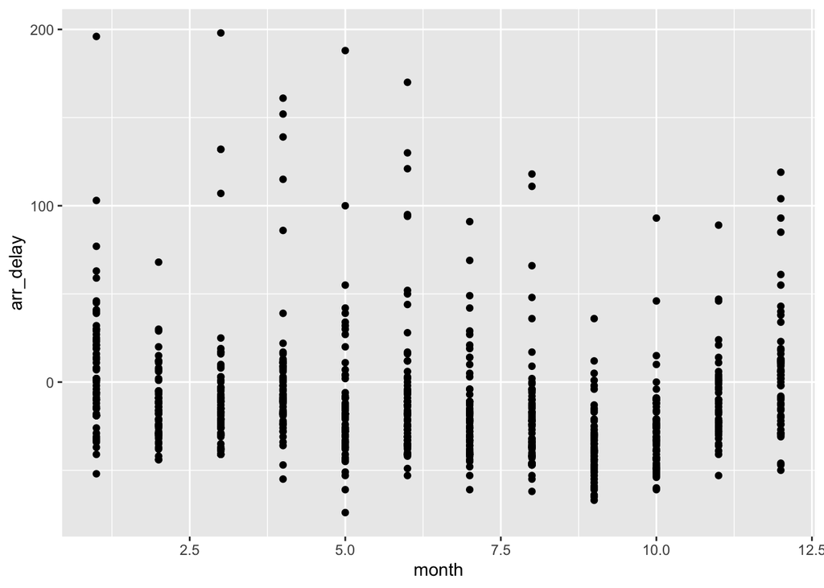

```r
ggplot(data = alaska_flights, aes(x = month, y = arr_delay)) +
  geom_point()
```

## Exercices 4.3.6

L’argument `stroke` permet de spécifier l’épaisseur des traits utilisés pour tracer les symboles (cercles, carrés, etc.) sur un graphique.

Création du jeu de données `diams` :

```r
set.seed(4532) # Afin que tout le monde récupère les mêmes lignes
diams <- diamonds %>%
  sample_n(5000)
```

Création du graphique :

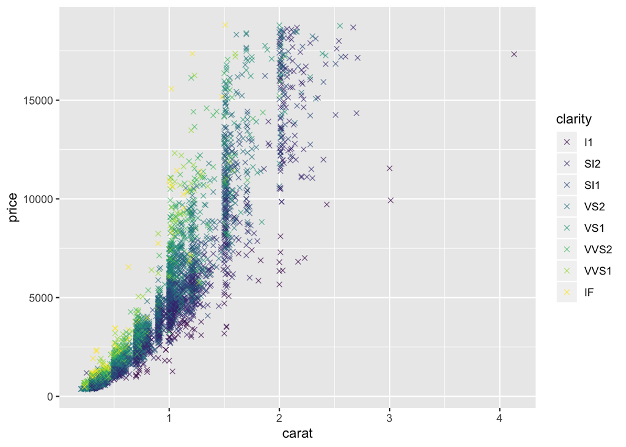

```r
ggplot(diams, aes(x = carat, y = price, color = clarity)) +
  geom_point(shape = 4, alpha = 0.6)
```

Revenir sur la position des arguments esthétiques : dans `ggplot()` ou dans `geom_XXX()` ?

- À quoi sont dues les bandes verticales ?*

Les bandes verticales sont le résultat d’approximations humaines. On a tendance à arrondir au carat “rond” immédiatement supérieur (2 au lieu de 1.98, 1.7 au lieu de 1.69, etc), car la valeur marchande dépend du carat.

## Exercices 4.4.2

Création du jeu de données `small_weather` :

```r
small_weather <- weather %>%
  filter(origin == "EWR",
         month == 1,
         day <= 15)

small_weather
```

```
## # A tibble: 358 x 15
##    origin  year month   day  hour  temp  dewp humid wind_dir wind_speed
##    <chr>  <dbl> <dbl> <int> <int> <dbl> <dbl> <dbl>    <dbl>      <dbl>
##  1 EWR     2013     1     1     1  39.0  26.1  59.4      270      10.4
##  2 EWR     2013     1     1     2  39.0  27.0  61.6      250       8.06
##  3 EWR     2013     1     1     3  39.0  28.0  64.4      240      11.5
##  4 EWR     2013     1     1     4  39.9  28.0  62.2      250      12.7
##  5 EWR     2013     1     1     5  39.0  28.0  64.4      260      12.7
##  6 EWR     2013     1     1     6  37.9  28.0  67.2      240      11.5
##  7 EWR     2013     1     1     7  39.0  28.0  64.4      240      15.0
##  8 EWR     2013     1     1     8  39.9  28.0  62.2      250      10.4
##  9 EWR     2013     1     1     9  39.9  28.0  62.2      260      15.0
## 10 EWR     2013     1     1    10  41    28.0  59.6      260      13.8
## # … with 348 more rows, and 5 more variables: wind_gust <dbl>,
## #   precip <dbl>, pressure <dbl>, visib <dbl>, time_hour <dttm>
```

*Expliquez pourquoi la variable `time_hour` identifie de manière unique le moment ou chaque mesure a été réalisée alors que ce n’est pas le cas de la variable `hour`.*

`hour` est une variable entière qui prend les valeurs 0 à 23 chaque jour de l’année. Indiquer qu’une mesure a été faite à 13h n’est pas suffisant car elle a pu être faite n’importe que jour. La variable `time-hour` contient la date et l’heure de chaque mesure, ce qui en fait un identifiant unique de chaque mesure.

## Exercices 4.6.3

*Examinez la figure 4.37.*

*1. Quels éléments nouveaux ce graphiques nous apprend-il par rapport au graphique 4.34 ci-dessus ? Comment le “faceting” nous aide-t’il à visualiser les relations entre 2 (ou 3) variables ?*

La nature bimodale de la distribution de la première figure cache en fait une distribution mensuelle des températures unimodale tout à fait classique, et ce, pour les 3 aéroports. Ce graphique nous permet également de visualiser la variabilité mensuelle, annuelle, et entre les aéroports ce qui était impossible avec l’histogramme synthétique de la figure 4.34.

- Les comparaisons en ligne nous permettent de comparer les température pour un mois donné entre les 3 aéroports. Nous constatons ici que ces températures sont toujours très similaires. Les distributions des températures dans les 3 aéroports de NY sont très proches. Ce qui est finalement tout à fait normal compte tenu de leur proximité géographique.
- Les comparaisons en colonnes nous permettent de visualiser l’évolution mensuelle des températures pour un aéroport donné. Ici, on constate que l’amplitude varie, de même que la position des pics : il fait plus chaud l’été que l’hiver. Là encore, c’est logique, nous sommes dans l’hémisphère Nord.

*2. À quoi correspondent les numéros 1 à 12 ?*

Aux mois de l’année

*3. À quoi correspondent les chiffres 25, 50, 75, 100 ?*

Aux températures en degrés farenheit

*4. À quoi correspondent les chiffres 0, 100, 200, 300 ?*

Au nombre d’observations pour chaque catégorie

*5. Observez les échelles des axes `x` et `y` pour chaque sous graphique. Qu’on-t’elles de particulier ? En quoi est-ce utile ?*

Elles sont toutes identiques. Elles facilitent ainsi les comparaisons entre sous-graphiques. Nous verrons peut-être plus tard que ce n’est pas toujours souhaitable.

*6. La variabilité des températures est-elle plus importante entre les aéroports, entre les mois, ou au sein des mois ? Expliquez votre réflexion.*

La variabilité des températures entre aéroports est très faible : pour un mois donné, les températures observées sont distribuées de façon très similaire dans les 3 aéroports. La variabilité entre les mois est plus importante : au sein d’un mois, la distribution des températures couvre rarement plus de 30º Farenheit alors qu’elle atteint presque 50º Farenheit entre les mois d’été et les mois d’hiver.

# Séance 4 : correction des exercices

## Exercice 4.8.3

*1. Quelle est la différence entre un histogramme et un diagramme bâtons ?*

- Un histogramme permet de visualiser la distribution d’une variable continue.
- Un diagramme bâtons permet de visualiser la distribution d’une variable catégorielle

*2. Pourquoi les histogrammes sont-ils inadaptés pour visualiser des données catégorielles ?*

Parce que les barres sont collées les unes aux autres ce qui donne une impression visuelle de continuité. Par ailleurs, les barres ne peuvent pas être ré-ordonnées, ce qui est souvent nécessaire pour une variable catégorielle.

*3. Quel est le nom de la companie pour laquelle le plus grand nombre de vols ont quitté New York en 2013 (je veux connaître son nom, pas juste son code) ? Où se trouve cette information ?*

On examine la figure 4.47 (par exemple) et on constate que la compagnie en question a le code `UA`. Le nom complet de cette compagnie se trouve dans le tableau `airlines`. Ce tableau fait le lien entre codes et nom des compagnies aériennes.

La compagnie qui a affrété le plus grand nombre de vols au départ de New York en 2013 est United Air Lines Inc.

```r
airlines
```

```
## # A tibble: 16 x 2
##    carrier name
##    <chr>   <chr>
##  1 9E      Endeavor Air Inc.
##  2 AA      American Airlines Inc.
##  3 AS      Alaska Airlines Inc.
##  4 B6      JetBlue Airways
##  5 DL      Delta Air Lines Inc.
##  6 EV      ExpressJet Airlines Inc.
##  7 F9      Frontier Airlines Inc.
##  8 FL      AirTran Airways Corporation
##  9 HA      Hawaiian Airlines Inc.
## 10 MQ      Envoy Air
## 11 OO      SkyWest Airlines Inc.
## 12 UA      United Air Lines Inc.
## 13 US      US Airways Inc.
## 14 VX      Virgin America
## 15 WN      Southwest Airlines Co.
## 16 YV      Mesa Airlines Inc.
```

*4. Quel est le nom de la companie pour laquelle le plus petit nombre de vols ont quitté New York en 2013 (je veux connaître son nom, pas juste son code) ? Où se trouve cette information ?*

Même démarche : il s’agit de la compagnie Skywest Airlines Inc. (code `OO`).

## Exercices 4.8.4

La figure 4.47 et la tableau `carrier_table` permettent de répondre aux questions suivantes

*Comparez les compagnies ExpressJet Airlines (EV) et US Airways (US). De combien de fois la part de EV est-elle supérieure à celle d’US ? (2 fois, 3 fois, 1.2 fois ?…)*

Un peu plus de 2,5

*Quelle est la troisième compagnie aérienne la plus importante en terme de nombre de vols au départ de New York en 2013 ?*

ExpressJet Airlines (`EV`)

*Combien de companies aériennes ont moins de vols que United Airlines (`UA`) ?*

Toutes, soit 15 au total